# Risk Factor Analysis

## Outcome Variable

**Outcome Variable:** y_rate_haz

## Predictor Variables

**Intervention Variable:** pers_wast

**Adjustment Set:**

- arm
- sex
- W_mage
- meducyrs
- W_nrooms
- month
- brthmon
- impfloor
- delta_W_mage
- delta_meducyrs
- delta_W_nrooms
- delta_month
- delta_brthmon
- delta_impfloor

## Stratifying Variables

The analysis was stratified on these variable(s):

- agecat
- studyid
- country

## Data Summary

| agecat | studyid | country | pers_wast | n_cell | n |
| --- | --- | --- | --- | --- | --- |
| 0-3 months | ki0047075b-MAL-ED | BANGLADESH | 0 | 237 | 244 |
| 0-3 months | ki0047075b-MAL-ED | BANGLADESH | 1 | 7 | 244 |
| 0-3 months | ki0047075b-MAL-ED | BRAZIL | 0 | 180 | 180 |
| 0-3 months | ki0047075b-MAL-ED | BRAZIL | 1 | 0 | 180 |
| 0-3 months | ki0047075b-MAL-ED | INDIA | 0 | 187 | 201 |
| 0-3 months | ki0047075b-MAL-ED | INDIA | 1 | 14 | 201 |
| 0-3 months | ki0047075b-MAL-ED | NEPAL | 0 | 172 | 175 |
| 0-3 months | ki0047075b-MAL-ED | NEPAL | 1 | 3 | 175 |
| 0-3 months | ki0047075b-MAL-ED | PERU | 0 | 271 | 271 |
| 0-3 months | ki0047075b-MAL-ED | PERU | 1 | 0 | 271 |
| 0-3 months | ki0047075b-MAL-ED | SOUTH AFRICA | 0 | 227 | 229 |
| 0-3 months | ki0047075b-MAL-ED | SOUTH AFRICA | 1 | 2 | 229 |
| 0-3 months | ki0047075b-MAL-ED | TANZANIA, UNITED REPUBLIC OF | 0 | 229 | 229 |
| 0-3 months | ki0047075b-MAL-ED | TANZANIA, UNITED REPUBLIC OF | 1 | 0 | 229 |
| 0-3 months | ki1000108-CMC-V-BCS-2002 | INDIA | 0 | 78 | 87 |
| 0-3 months | ki1000108-CMC-V-BCS-2002 | INDIA | 1 | 9 | 87 |
| 0-3 months | ki1000108-IRC | INDIA | 0 | 310 | 377 |
| 0-3 months | ki1000108-IRC | INDIA | 1 | 67 | 377 |
| 0-3 months | ki1000109-EE | PAKISTAN | 0 | 554 | 594 |
| 0-3 months | ki1000109-EE | PAKISTAN | 1 | 40 | 594 |
| 0-3 months | ki1000109-ResPak | PAKISTAN | 0 | 69 | 78 |
| 0-3 months | ki1000109-ResPak | PAKISTAN | 1 | 9 | 78 |
| 0-3 months | ki1017093b-PROVIDE | BANGLADESH | 0 | 619 | 634 |
| 0-3 months | ki1017093b-PROVIDE | BANGLADESH | 1 | 15 | 634 |
| 0-3 months | ki1101329-Keneba | GAMBIA | 0 | 1246 | 1276 |
| 0-3 months | ki1101329-Keneba | GAMBIA | 1 | 30 | 1276 |
| 0-3 months | ki1114097-CMIN | BANGLADESH | 0 | 41 | 43 |
| 0-3 months | ki1114097-CMIN | BANGLADESH | 1 | 2 | 43 |
| 0-3 months | ki1114097-CMIN | PERU | 0 | 89 | 93 |
| 0-3 months | ki1114097-CMIN | PERU | 1 | 4 | 93 |

[output cut: 108 more lines]

The following strata were considered:

- agecat: 0-3 months, studyid: ki0047075b-MAL-ED, country: BANGLADESH
- agecat: 0-3 months, studyid: ki0047075b-MAL-ED, country: BRAZIL
- agecat: 0-3 months, studyid: ki0047075b-MAL-ED, country: INDIA
- agecat: 0-3 months, studyid: ki0047075b-MAL-ED, country: NEPAL
- agecat: 0-3 months, studyid: ki0047075b-MAL-ED, country: PERU
- agecat: 0-3 months, studyid: ki0047075b-MAL-ED, country: SOUTH AFRICA
- agecat: 0-3 months, studyid: ki0047075b-MAL-ED, country: TANZANIA, UNITED REPUBLIC OF
- agecat: 0-3 months, studyid: ki1000108-CMC-V-BCS-2002, country: INDIA
- agecat: 0-3 months, studyid: ki1000108-IRC, country: INDIA
- agecat: 0-3 months, studyid: ki1000109-EE, country: PAKISTAN
- agecat: 0-3 months, studyid: ki1000109-ResPak, country: PAKISTAN
- agecat: 0-3 months, studyid: ki1017093b-PROVIDE, country: BANGLADESH
- agecat: 0-3 months, studyid: ki1101329-Keneba, country: GAMBIA
- agecat: 0-3 months, studyid: ki1114097-CMIN, country: BANGLADESH
- agecat: 0-3 months, studyid: ki1114097-CMIN, country: PERU
- agecat: 0-3 months, studyid: ki1114097-CONTENT, country: PERU
- agecat: 12-24 months, studyid: ki0047075b-MAL-ED, country: BANGLADESH
- agecat: 12-24 months, studyid: ki0047075b-MAL-ED, country: BRAZIL
- agecat: 12-24 months, studyid: ki0047075b-MAL-ED, country: INDIA
- agecat: 12-24 months, studyid: ki0047075b-MAL-ED, country: NEPAL
- agecat: 12-24 months, studyid: ki0047075b-MAL-ED, country: PERU
- agecat: 12-24 months, studyid: ki0047075b-MAL-ED, country: SOUTH AFRICA
- agecat: 12-24 months, studyid: ki0047075b-MAL-ED, country: TANZANIA, UNITED REPUBLIC OF
- agecat: 12-24 months, studyid: ki1000108-CMC-V-BCS-2002, country: INDIA
- agecat: 12-24 months, studyid: ki1000108-IRC, country: INDIA
- agecat: 12-24 months, studyid: ki1017093b-PROVIDE, country: BANGLADESH
- agecat: 12-24 months, studyid: ki1066203-TanzaniaChild2, country: TANZANIA, UNITED REPUBLIC OF
- agecat: 12-24 months, studyid: ki1101329-Keneba, country: GAMBIA
- agecat: 12-24 months, studyid: ki1113344-GMS-Nepal, country: NEPAL
- agecat: 12-24 months, studyid: ki1114097-CMIN, country: BANGLADESH
- agecat: 12-24 months, studyid: ki1114097-CMIN, country: PERU
- agecat: 12-24 months, studyid: ki1114097-CONTENT, country: PERU
- agecat: 3-6 months, studyid: ki0047075b-MAL-ED, country: BANGLADESH
- agecat: 3-6 months, studyid: ki0047075b-MAL-ED, country: BRAZIL
- agecat: 3-6 months, studyid: ki0047075b-MAL-ED, country: INDIA
- agecat: 3-6 months, studyid: ki0047075b-MAL-ED, country: NEPAL
- agecat: 3-6 months, studyid: ki0047075b-MAL-ED, country: PERU
- agecat: 3-6 months, studyid: ki0047075b-MAL-ED, country: SOUTH AFRICA
- agecat: 3-6 months, studyid: ki0047075b-MAL-ED, country: TANZANIA, UNITED REPUBLIC OF
- agecat: 3-6 months, studyid: ki1000108-CMC-V-BCS-2002, country: INDIA
- agecat: 3-6 months, studyid: ki1000108-IRC, country: INDIA
- agecat: 3-6 months, studyid: ki1000109-EE, country: PAKISTAN
- agecat: 3-6 months, studyid: ki1000109-ResPak, country: PAKISTAN
- agecat: 3-6 months, studyid: ki1017093b-PROVIDE, country: BANGLADESH
- agecat: 3-6 months, studyid: ki1066203-TanzaniaChild2, country: TANZANIA, UNITED REPUBLIC OF
- agecat: 3-6 months, studyid: ki1101329-Keneba, country: GAMBIA
- agecat: 3-6 months, studyid: ki1113344-GMS-Nepal, country: NEPAL
- agecat: 3-6 months, studyid: ki1114097-CMIN, country: BANGLADESH
- agecat: 3-6 months, studyid: ki1114097-CMIN, country: PERU
- agecat: 3-6 months, studyid: ki1114097-CONTENT, country: PERU
- agecat: 6-12 months, studyid: ki0047075b-MAL-ED, country: BANGLADESH
- agecat: 6-12 months, studyid: ki0047075b-MAL-ED, country: BRAZIL
- agecat: 6-12 months, studyid: ki0047075b-MAL-ED, country: INDIA
- agecat: 6-12 months, studyid: ki0047075b-MAL-ED, country: NEPAL
- agecat: 6-12 months, studyid: ki0047075b-MAL-ED, country: PERU
- agecat: 6-12 months, studyid: ki0047075b-MAL-ED, country: SOUTH AFRICA
- agecat: 6-12 months, studyid: ki0047075b-MAL-ED, country: TANZANIA, UNITED REPUBLIC OF
- agecat: 6-12 months, studyid: ki1000108-CMC-V-BCS-2002, country: INDIA
- agecat: 6-12 months, studyid: ki1000108-IRC, country: INDIA
- agecat: 6-12 months, studyid: ki1000109-EE, country: PAKISTAN
- agecat: 6-12 months, studyid: ki1000109-ResPak, country: PAKISTAN
- agecat: 6-12 months, studyid: ki1017093b-PROVIDE, country: BANGLADESH
- agecat: 6-12 months, studyid: ki1066203-TanzaniaChild2, country: TANZANIA, UNITED REPUBLIC OF
- agecat: 6-12 months, studyid: ki1101329-Keneba, country: GAMBIA
- agecat: 6-12 months, studyid: ki1112895-Guatemala BSC, country: GUATEMALA
- agecat: 6-12 months, studyid: ki1113344-GMS-Nepal, country: NEPAL
- agecat: 6-12 months, studyid: ki1114097-CMIN, country: BANGLADESH
- agecat: 6-12 months, studyid: ki1114097-CMIN, country: PERU
- agecat: 6-12 months, studyid: ki1114097-CONTENT, country: PERU

### Dropped Strata

Some strata were dropped due to rare outcomes:

- agecat: 0-3 months, studyid: ki0047075b-MAL-ED, country: BRAZIL
- agecat: 0-3 months, studyid: ki0047075b-MAL-ED, country: NEPAL
- agecat: 0-3 months, studyid: ki0047075b-MAL-ED, country: PERU
- agecat: 0-3 months, studyid: ki0047075b-MAL-ED, country: SOUTH AFRICA
- agecat: 0-3 months, studyid: ki0047075b-MAL-ED, country: TANZANIA, UNITED REPUBLIC OF
- agecat: 0-3 months, studyid: ki1114097-CMIN, country: BANGLADESH
- agecat: 0-3 months, studyid: ki1114097-CMIN, country: PERU
- agecat: 0-3 months, studyid: ki1114097-CONTENT, country: PERU
- agecat: 3-6 months, studyid: ki0047075b-MAL-ED, country: BRAZIL
- agecat: 3-6 months, studyid: ki0047075b-MAL-ED, country: NEPAL
- agecat: 3-6 months, studyid: ki0047075b-MAL-ED, country: PERU
- agecat: 3-6 months, studyid: ki0047075b-MAL-ED, country: SOUTH AFRICA
- agecat: 3-6 months, studyid: ki0047075b-MAL-ED, country: TANZANIA, UNITED REPUBLIC OF
- agecat: 3-6 months, studyid: ki1114097-CONTENT, country: PERU
- agecat: 6-12 months, studyid: ki0047075b-MAL-ED, country: BRAZIL
- agecat: 6-12 months, studyid: ki0047075b-MAL-ED, country: NEPAL
- agecat: 6-12 months, studyid: ki0047075b-MAL-ED, country: PERU
- agecat: 6-12 months, studyid: ki0047075b-MAL-ED, country: SOUTH AFRICA
- agecat: 6-12 months, studyid: ki0047075b-MAL-ED, country: TANZANIA, UNITED REPUBLIC OF
- agecat: 6-12 months, studyid: ki1000109-EE, country: PAKISTAN
- agecat: 6-12 months, studyid: ki1112895-Guatemala BSC, country: GUATEMALA
- agecat: 6-12 months, studyid: ki1114097-CONTENT, country: PERU
- agecat: 12-24 months, studyid: ki0047075b-MAL-ED, country: BRAZIL
- agecat: 12-24 months, studyid: ki0047075b-MAL-ED, country: NEPAL
- agecat: 12-24 months, studyid: ki0047075b-MAL-ED, country: PERU
- agecat: 12-24 months, studyid: ki0047075b-MAL-ED, country: SOUTH AFRICA
- agecat: 12-24 months, studyid: ki0047075b-MAL-ED, country: TANZANIA, UNITED REPUBLIC OF
- agecat: 12-24 months, studyid: ki1066203-TanzaniaChild2, country: TANZANIA, UNITED REPUBLIC OF
- agecat: 12-24 months, studyid: ki1114097-CMIN, country: BANGLADESH
- agecat: 12-24 months, studyid: ki1114097-CMIN, country: PERU
- agecat: 12-24 months, studyid: ki1114097-CONTENT, country: PERU

## Methods Detail

We’re interested in the causal parameters $E[Y_a]$ for all values of $a \in \mathcal{A}$. These parameters represent the mean outcome if, possibly contrary to fact, we intervened to set all units to have $A=a$. Under the randomization and positivity assumptions, these are identified by the statistical parameters $\psi_a=E_W[E_{Y|A,W}(Y|A=a,W)]$. In addition, we’re interested in the mean of $Y$, $E[Y]$ under no intervention (the observed mean). We will estimate these parameters by using SuperLearner to fit the relevant likelihood factors – $E_{Y|A,W}(Y|A=a,W)$ and $p(A=a|W)$, and then updating our likelihood fit using a joint TMLE.

For unadjusted analyses ($W=\{\}$), initial likelihoods were estimated using Lrnr_glm to estimate the simple $E(Y|A)$ and Lrnr_mean to estimate $p(A)$. For adjusted analyses, a small library containing Lrnr_glmnet, Lrnr_xgboost, and Lrnr_mean was used.

Having estimated these parameters, we will then use the delta method to estimate relative risks and attributable risks relative to a prespecified baseline level of $A$.

# Results Detail

## Results Plots

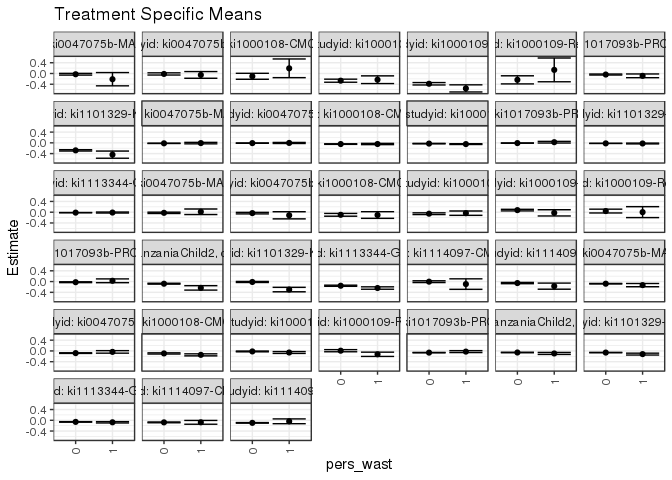

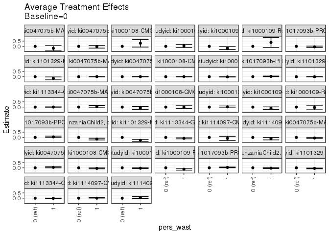

## Results Table

### Parameter: TSM

| agecat | studyid | country | intervention_level | baseline_level | estimate | ci_lower | ci_upper |
| --- | --- | --- | --- | --- | --- | --- | --- |
| 0-3 months | ki0047075b-MAL-ED | BANGLADESH | 0 | NA | -0.0286106 | -0.0605700 | 0.0033487 |
| 0-3 months | ki0047075b-MAL-ED | BANGLADESH | 1 | NA | -0.2132003 | -0.4597993 | 0.0333988 |
| 0-3 months | ki0047075b-MAL-ED | INDIA | 0 | NA | -0.0170358 | -0.0582071 | 0.0241354 |
| 0-3 months | ki0047075b-MAL-ED | INDIA | 1 | NA | -0.0536511 | -0.1779791 | 0.0706769 |
| 0-3 months | ki1000108-CMC-V-BCS-2002 | INDIA | 0 | NA | -0.1039000 | -0.2146985 | 0.0068985 |
| 0-3 months | ki1000108-CMC-V-BCS-2002 | INDIA | 1 | NA | 0.1919466 | -0.1556558 | 0.5395490 |
| 0-3 months | ki1000108-IRC | INDIA | 0 | NA | -0.2680791 | -0.3256267 | -0.2105315 |
| 0-3 months | ki1000108-IRC | INDIA | 1 | NA | -0.2319757 | -0.3754373 | -0.0885142 |
| 0-3 months | ki1000109-EE | PAKISTAN | 0 | NA | -0.3822392 | -0.4266015 | -0.3378770 |
| 0-3 months | ki1000109-EE | PAKISTAN | 1 | NA | -0.5546836 | -0.6870335 | -0.4223336 |
| 0-3 months | ki1000109-ResPak | PAKISTAN | 0 | NA | -0.2362023 | -0.3866052 | -0.0857993 |
| 0-3 months | ki1000109-ResPak | PAKISTAN | 1 | NA | 0.1339200 | -0.3078040 | 0.5756439 |
| 0-3 months | ki1017093b-PROVIDE | BANGLADESH | 0 | NA | -0.0391335 | -0.0574083 | -0.0208587 |
| 0-3 months | ki1017093b-PROVIDE | BANGLADESH | 1 | NA | -0.0876665 | -0.1572098 | -0.0181233 |
| 0-3 months | ki1101329-Keneba | GAMBIA | 0 | NA | -0.2794299 | -0.3032357 | -0.2556241 |
| 0-3 months | ki1101329-Keneba | GAMBIA | 1 | NA | -0.4389366 | -0.5721895 | -0.3056836 |
| 3-6 months | ki0047075b-MAL-ED | BANGLADESH | 0 | NA | -0.0233773 | -0.0468832 | 0.0001285 |
| 3-6 months | ki0047075b-MAL-ED | BANGLADESH | 1 | NA | 0.0161823 | -0.0869137 | 0.1192783 |
| 3-6 months | ki0047075b-MAL-ED | INDIA | 0 | NA | -0.0337625 | -0.0622693 | -0.0052557 |
| 3-6 months | ki0047075b-MAL-ED | INDIA | 1 | NA | -0.1147088 | -0.2473934 | 0.0179758 |
| 3-6 months | ki1000108-CMC-V-BCS-2002 | INDIA | 0 | NA | -0.0969043 | -0.1485086 | -0.0452999 |
| 3-6 months | ki1000108-CMC-V-BCS-2002 | INDIA | 1 | NA | -0.1042809 | -0.2280103 | 0.0194484 |
| 3-6 months | ki1000108-IRC | INDIA | 0 | NA | -0.0552177 | -0.0874681 | -0.0229673 |
| 3-6 months | ki1000108-IRC | INDIA | 1 | NA | -0.0358004 | -0.1164384 | 0.0448376 |
| 3-6 months | ki1000109-EE | PAKISTAN | 0 | NA | 0.0776981 | 0.0490647 | 0.1063316 |
| 3-6 months | ki1000109-EE | PAKISTAN | 1 | NA | -0.0240869 | -0.1401497 | 0.0919758 |
| 3-6 months | ki1000109-ResPak | PAKISTAN | 0 | NA | 0.0421993 | -0.0278902 | 0.1122887 |
| 3-6 months | ki1000109-ResPak | PAKISTAN | 1 | NA | 0.0024954 | -0.2006575 | 0.2056484 |
| 3-6 months | ki1017093b-PROVIDE | BANGLADESH | 0 | NA | -0.0239939 | -0.0404266 | -0.0075612 |
| 3-6 months | ki1017093b-PROVIDE | BANGLADESH | 1 | NA | 0.0291588 | -0.0410224 | 0.0993400 |
| 3-6 months | ki1066203-TanzaniaChild2 | TANZANIA, UNITED REPUBLIC OF | 0 | NA | -0.0800190 | -0.0967876 | -0.0632504 |
| 3-6 months | ki1066203-TanzaniaChild2 | TANZANIA, UNITED REPUBLIC OF | 1 | NA | -0.2344323 | -0.3164252 | -0.1524395 |
| 3-6 months | ki1101329-Keneba | GAMBIA | 0 | NA | -0.0151492 | -0.0335540 | 0.0032557 |
| 3-6 months | ki1101329-Keneba | GAMBIA | 1 | NA | -0.2971760 | -0.3802936 | -0.2140584 |
| 3-6 months | ki1113344-GMS-Nepal | NEPAL | 0 | NA | -0.1552004 | -0.1750597 | -0.1353412 |
| 3-6 months | ki1113344-GMS-Nepal | NEPAL | 1 | NA | -0.2403310 | -0.2843635 | -0.1962985 |
| 3-6 months | ki1114097-CMIN | BANGLADESH | 0 | NA | -0.0037601 | -0.0359144 | 0.0283941 |
| 3-6 months | ki1114097-CMIN | BANGLADESH | 1 | NA | -0.0936023 | -0.2883756 | 0.1011709 |
| 3-6 months | ki1114097-CMIN | PERU | 0 | NA | -0.0556566 | -0.0782959 | -0.0330172 |
| 3-6 months | ki1114097-CMIN | PERU | 1 | NA | -0.1702414 | -0.2837168 | -0.0567660 |
| 6-12 months | ki0047075b-MAL-ED | BANGLADESH | 0 | NA | -0.0795412 | -0.0900028 | -0.0690796 |
| 6-12 months | ki0047075b-MAL-ED | BANGLADESH | 1 | NA | -0.1322607 | -0.1919120 | -0.0726094 |
| 6-12 months | ki0047075b-MAL-ED | INDIA | 0 | NA | -0.0814801 | -0.0937116 | -0.0692486 |
| 6-12 months | ki0047075b-MAL-ED | INDIA | 1 | NA | -0.0358980 | -0.0833182 | 0.0115221 |
| 6-12 months | ki1000108-CMC-V-BCS-2002 | INDIA | 0 | NA | -0.0928845 | -0.1152996 | -0.0704693 |
| 6-12 months | ki1000108-CMC-V-BCS-2002 | INDIA | 1 | NA | -0.1456576 | -0.1837652 | -0.1075500 |
| 6-12 months | ki1000108-IRC | INDIA | 0 | NA | -0.0189419 | -0.0324216 | -0.0054623 |
| 6-12 months | ki1000108-IRC | INDIA | 1 | NA | -0.0590237 | -0.0936551 | -0.0243922 |
| 6-12 months | ki1000109-ResPak | PAKISTAN | 0 | NA | 0.0082270 | -0.0309054 | 0.0473594 |
| 6-12 months | ki1000109-ResPak | PAKISTAN | 1 | NA | -0.1252383 | -0.2048515 | -0.0456251 |
| 6-12 months | ki1017093b-PROVIDE | BANGLADESH | 0 | NA | -0.0632758 | -0.0702663 | -0.0562853 |
| 6-12 months | ki1017093b-PROVIDE | BANGLADESH | 1 | NA | -0.0255068 | -0.0605812 | 0.0095677 |
| 6-12 months | ki1066203-TanzaniaChild2 | TANZANIA, UNITED REPUBLIC OF | 0 | NA | -0.0586527 | -0.0679777 | -0.0493277 |
| 6-12 months | ki1066203-TanzaniaChild2 | TANZANIA, UNITED REPUBLIC OF | 1 | NA | -0.0941447 | -0.1310634 | -0.0572260 |
| 6-12 months | ki1101329-Keneba | GAMBIA | 0 | NA | -0.0613847 | -0.0691933 | -0.0535760 |
| 6-12 months | ki1101329-Keneba | GAMBIA | 1 | NA | -0.1183318 | -0.1530834 | -0.0835803 |
| 6-12 months | ki1113344-GMS-Nepal | NEPAL | 0 | NA | -0.0596556 | -0.0683886 | -0.0509225 |
| 6-12 months | ki1113344-GMS-Nepal | NEPAL | 1 | NA | -0.0747283 | -0.0988827 | -0.0505739 |
| 6-12 months | ki1114097-CMIN | BANGLADESH | 0 | NA | -0.0773529 | -0.0925567 | -0.0621490 |
| 6-12 months | ki1114097-CMIN | BANGLADESH | 1 | NA | -0.0759161 | -0.1463436 | -0.0054885 |
| 6-12 months | ki1114097-CMIN | PERU | 0 | NA | -0.0953777 | -0.1058636 | -0.0848917 |
| 6-12 months | ki1114097-CMIN | PERU | 1 | NA | -0.0380500 | -0.1271317 | 0.0510317 |
| 12-24 months | ki0047075b-MAL-ED | BANGLADESH | 0 | NA | -0.0181076 | -0.0236072 | -0.0126079 |
| 12-24 months | ki0047075b-MAL-ED | BANGLADESH | 1 | NA | -0.0092299 | -0.0359091 | 0.0174494 |
| 12-24 months | ki0047075b-MAL-ED | INDIA | 0 | NA | -0.0104178 | -0.0157370 | -0.0050986 |
| 12-24 months | ki0047075b-MAL-ED | INDIA | 1 | NA | -0.0037359 | -0.0229648 | 0.0154931 |
| 12-24 months | ki1000108-CMC-V-BCS-2002 | INDIA | 0 | NA | -0.0449267 | -0.0562447 | -0.0336086 |
| 12-24 months | ki1000108-CMC-V-BCS-2002 | INDIA | 1 | NA | -0.0439017 | -0.0669743 | -0.0208291 |
| 12-24 months | ki1000108-IRC | INDIA | 0 | NA | -0.0280881 | -0.0355399 | -0.0206363 |
| 12-24 months | ki1000108-IRC | INDIA | 1 | NA | -0.0466443 | -0.0620508 | -0.0312379 |
| 12-24 months | ki1017093b-PROVIDE | BANGLADESH | 0 | NA | -0.0089780 | -0.0128091 | -0.0051470 |
| 12-24 months | ki1017093b-PROVIDE | BANGLADESH | 1 | NA | 0.0245712 | -0.0062862 | 0.0554287 |
| 12-24 months | ki1101329-Keneba | GAMBIA | 0 | NA | -0.0202088 | -0.0241236 | -0.0162940 |
| 12-24 months | ki1101329-Keneba | GAMBIA | 1 | NA | -0.0238552 | -0.0378277 | -0.0098827 |
| 12-24 months | ki1113344-GMS-Nepal | NEPAL | 0 | NA | -0.0159042 | -0.0210781 | -0.0107304 |
| 12-24 months | ki1113344-GMS-Nepal | NEPAL | 1 | NA | -0.0128692 | -0.0311687 | 0.0054302 |

### Parameter: E(Y)

| agecat | studyid | country | intervention_level | baseline_level | estimate | ci_lower | ci_upper |
| --- | --- | --- | --- | --- | --- | --- | --- |
| 0-3 months | ki0047075b-MAL-ED | BANGLADESH | NA | NA | -0.0339062 | -0.0659795 | -0.0018330 |
| 0-3 months | ki0047075b-MAL-ED | INDIA | NA | NA | -0.0204797 | -0.0596747 | 0.0187152 |
| 0-3 months | ki1000108-CMC-V-BCS-2002 | INDIA | NA | NA | -0.0732952 | -0.1806423 | 0.0340519 |
| 0-3 months | ki1000108-IRC | INDIA | NA | NA | -0.2594964 | -0.3154509 | -0.2035418 |
| 0-3 months | ki1000109-EE | PAKISTAN | NA | NA | -0.3938516 | -0.4364614 | -0.3512419 |
| 0-3 months | ki1000109-ResPak | PAKISTAN | NA | NA | -0.1934958 | -0.3384003 | -0.0485914 |
| 0-3 months | ki1017093b-PROVIDE | BANGLADESH | NA | NA | -0.0413143 | -0.0594662 | -0.0231624 |
| 0-3 months | ki1101329-Keneba | GAMBIA | NA | NA | -0.2850538 | -0.3091443 | -0.2609633 |
| 3-6 months | ki0047075b-MAL-ED | BANGLADESH | NA | NA | -0.0225211 | -0.0456381 | 0.0005960 |
| 3-6 months | ki0047075b-MAL-ED | INDIA | NA | NA | -0.0401251 | -0.0685271 | -0.0117231 |
| 3-6 months | ki1000108-CMC-V-BCS-2002 | INDIA | NA | NA | -0.0979615 | -0.1455947 | -0.0503283 |
| 3-6 months | ki1000108-IRC | INDIA | NA | NA | -0.0518918 | -0.0819849 | -0.0217987 |
| 3-6 months | ki1000109-EE | PAKISTAN | NA | NA | 0.0701161 | 0.0419135 | 0.0983187 |
| 3-6 months | ki1000109-ResPak | PAKISTAN | NA | NA | 0.0387792 | -0.0275800 | 0.1051384 |
| 3-6 months | ki1017093b-PROVIDE | BANGLADESH | NA | NA | -0.0272428 | -0.0436954 | -0.0107902 |
| 3-6 months | ki1066203-TanzaniaChild2 | TANZANIA, UNITED REPUBLIC OF | NA | NA | -0.0844665 | -0.1011169 | -0.0678162 |
| 3-6 months | ki1101329-Keneba | GAMBIA | NA | NA | -0.0167995 | -0.0352345 | 0.0016355 |
| 3-6 months | ki1113344-GMS-Nepal | NEPAL | NA | NA | -0.1659967 | -0.1845182 | -0.1474752 |
| 3-6 months | ki1114097-CMIN | BANGLADESH | NA | NA | -0.0085806 | -0.0411510 | 0.0239898 |
| 3-6 months | ki1114097-CMIN | PERU | NA | NA | -0.0576273 | -0.0800097 | -0.0352449 |
| 6-12 months | ki0047075b-MAL-ED | BANGLADESH | NA | NA | -0.0807393 | -0.0911050 | -0.0703737 |
| 6-12 months | ki0047075b-MAL-ED | INDIA | NA | NA | -0.0776724 | -0.0898619 | -0.0654829 |
| 6-12 months | ki1000108-CMC-V-BCS-2002 | INDIA | NA | NA | -0.1005481 | -0.1211684 | -0.0799278 |
| 6-12 months | ki1000108-IRC | INDIA | NA | NA | -0.0260151 | -0.0389122 | -0.0131180 |
| 6-12 months | ki1000109-ResPak | PAKISTAN | NA | NA | -0.0070783 | -0.0435451 | 0.0293884 |
| 6-12 months | ki1017093b-PROVIDE | BANGLADESH | NA | NA | -0.0626151 | -0.0695574 | -0.0556729 |
| 6-12 months | ki1066203-TanzaniaChild2 | TANZANIA, UNITED REPUBLIC OF | NA | NA | -0.0598587 | -0.0690454 | -0.0506721 |
| 6-12 months | ki1101329-Keneba | GAMBIA | NA | NA | -0.0617247 | -0.0695829 | -0.0538665 |
| 6-12 months | ki1113344-GMS-Nepal | NEPAL | NA | NA | -0.0614960 | -0.0697225 | -0.0532696 |
| 6-12 months | ki1114097-CMIN | BANGLADESH | NA | NA | -0.0773003 | -0.0921728 | -0.0624278 |
| 6-12 months | ki1114097-CMIN | PERU | NA | NA | -0.0939324 | -0.1044393 | -0.0834255 |
| 12-24 months | ki0047075b-MAL-ED | BANGLADESH | NA | NA | -0.0178490 | -0.0232486 | -0.0124494 |
| 12-24 months | ki0047075b-MAL-ED | INDIA | NA | NA | -0.0098833 | -0.0150187 | -0.0047479 |
| 12-24 months | ki1000108-CMC-V-BCS-2002 | INDIA | NA | NA | -0.0447636 | -0.0549912 | -0.0345359 |
| 12-24 months | ki1000108-IRC | INDIA | NA | NA | -0.0317687 | -0.0388357 | -0.0247017 |
| 12-24 months | ki1017093b-PROVIDE | BANGLADESH | NA | NA | -0.0081718 | -0.0120131 | -0.0043304 |
| 12-24 months | ki1101329-Keneba | GAMBIA | NA | NA | -0.0201603 | -0.0240062 | -0.0163144 |
| 12-24 months | ki1113344-GMS-Nepal | NEPAL | NA | NA | -0.0155649 | -0.0206065 | -0.0105234 |

### Parameter: ATE

| agecat | studyid | country | intervention_level | baseline_level | estimate | ci_lower | ci_upper |
| --- | --- | --- | --- | --- | --- | --- | --- |
| 0-3 months | ki0047075b-MAL-ED | BANGLADESH | 0 | 0 | 0.0000000 | 0.0000000 | 0.0000000 |
| 0-3 months | ki0047075b-MAL-ED | BANGLADESH | 1 | 0 | -0.1845896 | -0.4332510 | 0.0640718 |
| 0-3 months | ki0047075b-MAL-ED | INDIA | 0 | 0 | 0.0000000 | 0.0000000 | 0.0000000 |
| 0-3 months | ki0047075b-MAL-ED | INDIA | 1 | 0 | -0.0366153 | -0.1676978 | 0.0944673 |
| 0-3 months | ki1000108-CMC-V-BCS-2002 | INDIA | 0 | 0 | 0.0000000 | 0.0000000 | 0.0000000 |
| 0-3 months | ki1000108-CMC-V-BCS-2002 | INDIA | 1 | 0 | 0.2958466 | -0.0689872 | 0.6606804 |
| 0-3 months | ki1000108-IRC | INDIA | 0 | 0 | 0.0000000 | 0.0000000 | 0.0000000 |
| 0-3 months | ki1000108-IRC | INDIA | 1 | 0 | 0.0361034 | -0.1169928 | 0.1891996 |
| 0-3 months | ki1000109-EE | PAKISTAN | 0 | 0 | 0.0000000 | 0.0000000 | 0.0000000 |
| 0-3 months | ki1000109-EE | PAKISTAN | 1 | 0 | -0.1724443 | -0.3120293 | -0.0328593 |
| 0-3 months | ki1000109-ResPak | PAKISTAN | 0 | 0 | 0.0000000 | 0.0000000 | 0.0000000 |
| 0-3 months | ki1000109-ResPak | PAKISTAN | 1 | 0 | 0.3701222 | -0.0965051 | 0.8367496 |
| 0-3 months | ki1017093b-PROVIDE | BANGLADESH | 0 | 0 | 0.0000000 | 0.0000000 | 0.0000000 |
| 0-3 months | ki1017093b-PROVIDE | BANGLADESH | 1 | 0 | -0.0485330 | -0.1204638 | 0.0233977 |
| 0-3 months | ki1101329-Keneba | GAMBIA | 0 | 0 | 0.0000000 | 0.0000000 | 0.0000000 |
| 0-3 months | ki1101329-Keneba | GAMBIA | 1 | 0 | -0.1595067 | -0.2950407 | -0.0239726 |
| 3-6 months | ki0047075b-MAL-ED | BANGLADESH | 0 | 0 | 0.0000000 | 0.0000000 | 0.0000000 |
| 3-6 months | ki0047075b-MAL-ED | BANGLADESH | 1 | 0 | 0.0395596 | -0.0661820 | 0.1453013 |
| 3-6 months | ki0047075b-MAL-ED | INDIA | 0 | 0 | 0.0000000 | 0.0000000 | 0.0000000 |
| 3-6 months | ki0047075b-MAL-ED | INDIA | 1 | 0 | -0.0809463 | -0.2166586 | 0.0547660 |
| 3-6 months | ki1000108-CMC-V-BCS-2002 | INDIA | 0 | 0 | 0.0000000 | 0.0000000 | 0.0000000 |
| 3-6 months | ki1000108-CMC-V-BCS-2002 | INDIA | 1 | 0 | -0.0073767 | -0.1414362 | 0.1266829 |
| 3-6 months | ki1000108-IRC | INDIA | 0 | 0 | 0.0000000 | 0.0000000 | 0.0000000 |
| 3-6 months | ki1000108-IRC | INDIA | 1 | 0 | 0.0194173 | -0.0674307 | 0.1062654 |
| 3-6 months | ki1000109-EE | PAKISTAN | 0 | 0 | 0.0000000 | 0.0000000 | 0.0000000 |
| 3-6 months | ki1000109-EE | PAKISTAN | 1 | 0 | -0.1017851 | -0.2209851 | 0.0174150 |
| 3-6 months | ki1000109-ResPak | PAKISTAN | 0 | 0 | 0.0000000 | 0.0000000 | 0.0000000 |
| 3-6 months | ki1000109-ResPak | PAKISTAN | 1 | 0 | -0.0397039 | -0.2547152 | 0.1753075 |
| 3-6 months | ki1017093b-PROVIDE | BANGLADESH | 0 | 0 | 0.0000000 | 0.0000000 | 0.0000000 |
| 3-6 months | ki1017093b-PROVIDE | BANGLADESH | 1 | 0 | 0.0531527 | -0.0189510 | 0.1252564 |
| 3-6 months | ki1066203-TanzaniaChild2 | TANZANIA, UNITED REPUBLIC OF | 0 | 0 | 0.0000000 | 0.0000000 | 0.0000000 |
| 3-6 months | ki1066203-TanzaniaChild2 | TANZANIA, UNITED REPUBLIC OF | 1 | 0 | -0.1544133 | -0.2379453 | -0.0708814 |
| 3-6 months | ki1101329-Keneba | GAMBIA | 0 | 0 | 0.0000000 | 0.0000000 | 0.0000000 |
| 3-6 months | ki1101329-Keneba | GAMBIA | 1 | 0 | -0.2820269 | -0.3671485 | -0.1969052 |
| 3-6 months | ki1113344-GMS-Nepal | NEPAL | 0 | 0 | 0.0000000 | 0.0000000 | 0.0000000 |
| 3-6 months | ki1113344-GMS-Nepal | NEPAL | 1 | 0 | -0.0851306 | -0.1333339 | -0.0369273 |
| 3-6 months | ki1114097-CMIN | BANGLADESH | 0 | 0 | 0.0000000 | 0.0000000 | 0.0000000 |
| 3-6 months | ki1114097-CMIN | BANGLADESH | 1 | 0 | -0.0898422 | -0.2872433 | 0.1075589 |
| 3-6 months | ki1114097-CMIN | PERU | 0 | 0 | 0.0000000 | 0.0000000 | 0.0000000 |
| 3-6 months | ki1114097-CMIN | PERU | 1 | 0 | -0.1145849 | -0.2302966 | 0.0011269 |
| 6-12 months | ki0047075b-MAL-ED | BANGLADESH | 0 | 0 | 0.0000000 | 0.0000000 | 0.0000000 |
| 6-12 months | ki0047075b-MAL-ED | BANGLADESH | 1 | 0 | -0.0527196 | -0.1132813 | 0.0078422 |
| 6-12 months | ki0047075b-MAL-ED | INDIA | 0 | 0 | 0.0000000 | 0.0000000 | 0.0000000 |
| 6-12 months | ki0047075b-MAL-ED | INDIA | 1 | 0 | 0.0455821 | -0.0031555 | 0.0943196 |
| 6-12 months | ki1000108-CMC-V-BCS-2002 | INDIA | 0 | 0 | 0.0000000 | 0.0000000 | 0.0000000 |
| 6-12 months | ki1000108-CMC-V-BCS-2002 | INDIA | 1 | 0 | -0.0527731 | -0.0967793 | -0.0087669 |
| 6-12 months | ki1000108-IRC | INDIA | 0 | 0 | 0.0000000 | 0.0000000 | 0.0000000 |
| 6-12 months | ki1000108-IRC | INDIA | 1 | 0 | -0.0400818 | -0.0771205 | -0.0030430 |
| 6-12 months | ki1000109-ResPak | PAKISTAN | 0 | 0 | 0.0000000 | 0.0000000 | 0.0000000 |
| 6-12 months | ki1000109-ResPak | PAKISTAN | 1 | 0 | -0.1334653 | -0.2221402 | -0.0447904 |
| 6-12 months | ki1017093b-PROVIDE | BANGLADESH | 0 | 0 | 0.0000000 | 0.0000000 | 0.0000000 |
| 6-12 months | ki1017093b-PROVIDE | BANGLADESH | 1 | 0 | 0.0377691 | 0.0020132 | 0.0735250 |
| 6-12 months | ki1066203-TanzaniaChild2 | TANZANIA, UNITED REPUBLIC OF | 0 | 0 | 0.0000000 | 0.0000000 | 0.0000000 |
| 6-12 months | ki1066203-TanzaniaChild2 | TANZANIA, UNITED REPUBLIC OF | 1 | 0 | -0.0354920 | -0.0734928 | 0.0025088 |
| 6-12 months | ki1101329-Keneba | GAMBIA | 0 | 0 | 0.0000000 | 0.0000000 | 0.0000000 |
| 6-12 months | ki1101329-Keneba | GAMBIA | 1 | 0 | -0.0569472 | -0.0925626 | -0.0213317 |
| 6-12 months | ki1113344-GMS-Nepal | NEPAL | 0 | 0 | 0.0000000 | 0.0000000 | 0.0000000 |
| 6-12 months | ki1113344-GMS-Nepal | NEPAL | 1 | 0 | -0.0150727 | -0.0407573 | 0.0106119 |
| 6-12 months | ki1114097-CMIN | BANGLADESH | 0 | 0 | 0.0000000 | 0.0000000 | 0.0000000 |
| 6-12 months | ki1114097-CMIN | BANGLADESH | 1 | 0 | 0.0014368 | -0.0706132 | 0.0734867 |
| 6-12 months | ki1114097-CMIN | PERU | 0 | 0 | 0.0000000 | 0.0000000 | 0.0000000 |
| 6-12 months | ki1114097-CMIN | PERU | 1 | 0 | 0.0573276 | -0.0323691 | 0.1470243 |
| 12-24 months | ki0047075b-MAL-ED | BANGLADESH | 0 | 0 | 0.0000000 | 0.0000000 | 0.0000000 |
| 12-24 months | ki0047075b-MAL-ED | BANGLADESH | 1 | 0 | 0.0088777 | -0.0183625 | 0.0361179 |
| 12-24 months | ki0047075b-MAL-ED | INDIA | 0 | 0 | 0.0000000 | 0.0000000 | 0.0000000 |
| 12-24 months | ki0047075b-MAL-ED | INDIA | 1 | 0 | 0.0066820 | -0.0132686 | 0.0266326 |
| 12-24 months | ki1000108-CMC-V-BCS-2002 | INDIA | 0 | 0 | 0.0000000 | 0.0000000 | 0.0000000 |
| 12-24 months | ki1000108-CMC-V-BCS-2002 | INDIA | 1 | 0 | 0.0010250 | -0.0245950 | 0.0266449 |
| 12-24 months | ki1000108-IRC | INDIA | 0 | 0 | 0.0000000 | 0.0000000 | 0.0000000 |
| 12-24 months | ki1000108-IRC | INDIA | 1 | 0 | -0.0185563 | -0.0355016 | -0.0016110 |
| 12-24 months | ki1017093b-PROVIDE | BANGLADESH | 0 | 0 | 0.0000000 | 0.0000000 | 0.0000000 |
| 12-24 months | ki1017093b-PROVIDE | BANGLADESH | 1 | 0 | 0.0335493 | 0.0024590 | 0.0646395 |
| 12-24 months | ki1101329-Keneba | GAMBIA | 0 | 0 | 0.0000000 | 0.0000000 | 0.0000000 |
| 12-24 months | ki1101329-Keneba | GAMBIA | 1 | 0 | -0.0036464 | -0.0181294 | 0.0108367 |
| 12-24 months | ki1113344-GMS-Nepal | NEPAL | 0 | 0 | 0.0000000 | 0.0000000 | 0.0000000 |
| 12-24 months | ki1113344-GMS-Nepal | NEPAL | 1 | 0 | 0.0030350 | -0.0159563 | 0.0220263 |